# Prediction Assignment

Yinning Zhang

October 17, 2018

## Summary

This project is created for the John Hopkins’s Practical Machine Learning course on Coursera. It uses the data from http://web.archive.org/web/20161224072740/http:/groupware.les.inf.puc-rio.br/har, which captures data from accelerometers on the belt, forearm, arm, and dumbell when the participants doing activities. This project is to find a model to predict the human activity with the data from accelerometers.

## Loading data and Preprocessing

1. Load data.

```r
library(data.table)
```

```r
training <- fread('https://d396qusza40orc.cloudfront.net/predmachlearn/pml-training.csv')
training <- data.frame(training)
testing <- fread('https://d396qusza40orc.cloudfront.net/predmachlearn/pml-testing.csv')
testing <- data.frame(testing)
dim(training)
```

```
## [1] 19622   160
```

```r
dim(testing)
```

```
## [1]  20 160
```

```r
training_new <- training[ , colSums(is.na(training)) == 0]
dim(training_new)
```

```
## [1] 19622    60
```

Apply this method to the testing data.

```r
testing_new <- testing[ ,  colSums(is.na(testing)) == 0]
dim(testing_new)
```

```
## [1] 20 60
```

3. Remove the columns with ID and timestamps

```r
training2 <- training_new[ , c(-1, -2, -3, -4, -5, -6, -7)]
testing2 <- testing_new[ , c(-1, -2, -3, -4, -5, -6, -7)]
```

4. Identify and remove near zero variance predictors

```r
library(caret)
nzv <- nearZeroVar(training2, saveMetrics = TRUE) # I print out nzv. The result shows that none shall be removed.
```

5. Remove high correlated variables.

```r
COR = cor(training2[, -53])
COR2 = findCorrelation(COR, cutoff = 0.8)
COR2 = sort(COR2)
training3 = training2[ , -c(COR2)]
dim(training3) # reduce to 40 variables
```

```
## [1] 19622    40
```

```r
testing3 =testing2[ , -c(COR2)]
dim(testing3)
```

```
## [1] 20 40
```

## Splitting the data

```r
library(caret)
inTrain <- createDataPartition(y = training3$classe, p=0.75, list = FALSE)
training_s <- training3[inTrain,]
testing_s <- training3[-inTrain, ]
dim(training_s); dim(testing_s)
```

```
## [1] 14718    40
```

```
## [1] 4904   40
```

## Predict with models and compare the accuracies.

1. Tree model

```r
modelTree <-  train(as.factor(classe)~., method = "rpart", preProcess = c("center", "scale"), data = training_s)
confusionMatrix(as.factor(training_s$classe), predict(modelTree, training_s))
```

```
## Confusion Matrix and Statistics
##
##           Reference
## Prediction    A    B    C    D    E
##          A 3814   62  239   67    3
##          B 1184  958  597  106    3
##          C 1192   81 1040  252    2
##          D  974  414  245  580  199
##          E  602  493  631   91  889
##
## Overall Statistics
##
##                Accuracy : 0.4947
##                  95% CI : (0.4866, 0.5028)
##     No Information Rate : 0.5277
##     P-Value [Acc > NIR] : 1
##
##                   Kappa : 0.3395
##  Mcnemar's Test P-Value : <2e-16
##
## Statistics by Class:
##
##                      Class: A Class: B Class: C Class: D Class: E
## Sensitivity            0.4911  0.47709  0.37791  0.52920  0.81113
## Specificity            0.9466  0.85130  0.87239  0.86551  0.86661
## Pos Pred Value         0.9114  0.33638  0.40514  0.24046  0.32853
## Neg Pred Value         0.6248  0.91154  0.85911  0.95807  0.98277
## Prevalence             0.5277  0.13643  0.18698  0.07447  0.07447
## Detection Rate         0.2591  0.06509  0.07066  0.03941  0.06040
## Detection Prevalence   0.2843  0.19350  0.17441  0.16388  0.18386
## Balanced Accuracy      0.7189  0.66419  0.62515  0.69735  0.83887
```

This accuracy is very low, so I give up this model and do not need to proceed.

2. Random Forest

```r
library(randomForest)
modelForest <- randomForest(as.factor(classe) ~., data = training_s, mtry=4, ntree=200, prox=TRUE, importance=TRUE)
modelForest
```

```
##
## Call:
##  randomForest(formula = as.factor(classe) ~ ., data = training_s,      mtry = 4, ntree = 200, prox = TRUE, importance = TRUE)
##                Type of random forest: classification
##                      Number of trees: 200
## No. of variables tried at each split: 4
##
##         OOB estimate of  error rate: 0.71%
## Confusion matrix:
##      A    B    C    D    E  class.error
## A 4182    3    0    0    0 0.0007168459
## B   16 2822   10    0    0 0.0091292135
## C    0   22 2539    6    0 0.0109076743
## D    0    0   37 2373    2 0.0161691542
## E    0    0    1    7 2698 0.0029563932
```

The accuracy seems very high. Now let’s plot the error vs Number of trees

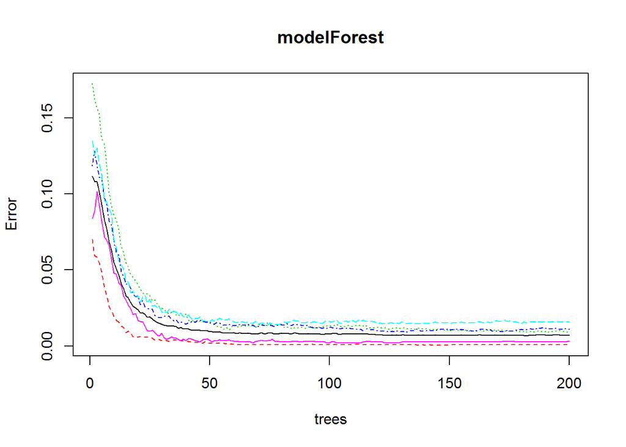

```r
plot(modelForest)
```

Refine this model to have only 50 trees, as the plot shows that the error rates stay even if you add trees over 50.

```r
modelForest2 <- randomForest(as.factor(classe) ~., data = training_s, mtry=4, ntree=50, prox=TRUE, importance=TRUE)
modelForest2
```

```
##
## Call:
##  randomForest(formula = as.factor(classe) ~ ., data = training_s,      mtry = 4, ntree = 50, prox = TRUE, importance = TRUE)
##                Type of random forest: classification
##                      Number of trees: 50
## No. of variables tried at each split: 4
##
##         OOB estimate of  error rate: 0.99%
## Confusion matrix:
##      A    B    C    D    E class.error
## A 4178    4    2    1    0 0.001672640
## B   22 2806   17    1    2 0.014747191
## C    1   29 2531    6    0 0.014024153
## D    2    1   46 2360    3 0.021558872
## E    0    1    2    6 2697 0.003325942
```

The error rate is still good; however this model with less trees is more efficient. Let’s use it.

Find the importance of the factors.

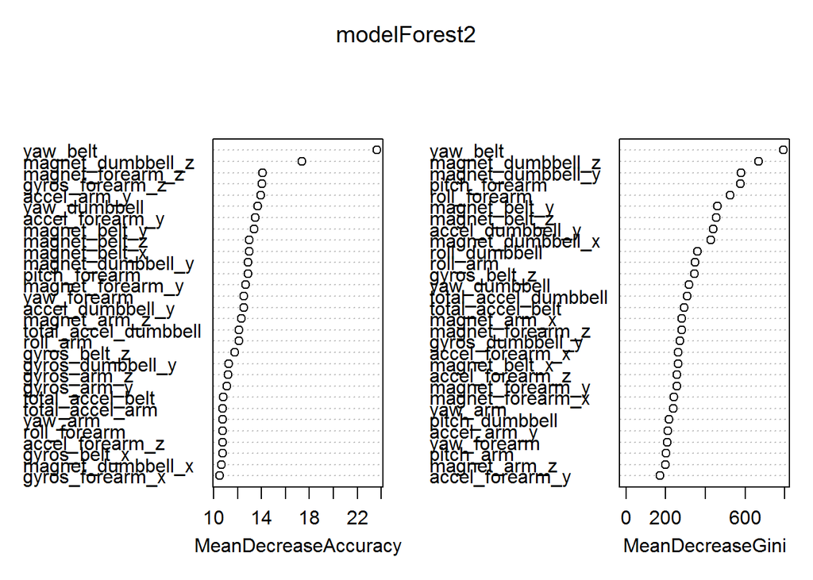

```r
varImpPlot(modelForest2,)
```

## Use the Radom Forest model to predict the testing data and see the accuracy.

```r
confusionMatrix(as.factor(testing_s$classe), predict(modelForest2, testing_s))
```

```
## Confusion Matrix and Statistics
##
##           Reference
## Prediction    A    B    C    D    E
##          A 1394    0    0    0    1
##          B   10  937    2    0    0
##          C    0    4  851    0    0
##          D    0    0   17  785    2
##          E    0    0    0    3  898
##
## Overall Statistics
##
##                Accuracy : 0.992
##                  95% CI : (0.9891, 0.9943)
##     No Information Rate : 0.2863
##     P-Value [Acc > NIR] : < 2.2e-16
##
##                   Kappa : 0.9899
##  Mcnemar's Test P-Value : NA
##
## Statistics by Class:
##
##                      Class: A Class: B Class: C Class: D Class: E
## Sensitivity            0.9929   0.9957   0.9782   0.9962   0.9967
## Specificity            0.9997   0.9970   0.9990   0.9954   0.9993
## Pos Pred Value         0.9993   0.9874   0.9953   0.9764   0.9967
## Neg Pred Value         0.9972   0.9990   0.9953   0.9993   0.9993
## Prevalence             0.2863   0.1919   0.1774   0.1607   0.1837
## Detection Rate         0.2843   0.1911   0.1735   0.1601   0.1831
## Detection Prevalence   0.2845   0.1935   0.1743   0.1639   0.1837
## Balanced Accuracy      0.9963   0.9964   0.9886   0.9958   0.9980
```

The accuracy is good on the testing data as well. Now, I use this model to predict the data from the questionaires.

```r
print(predict(modelForest2, testing3[, c(1:39)]))
```

```
##  1  2  3  4  5  6  7  8  9 10 11 12 13 14 15 16 17 18 19 20
##  B  A  B  A  A  E  D  B  A  A  B  C  B  A  E  E  A  B  B  B
## Levels: A B C D E
```